# Statistical Analysis

Cover Wu

2021/2/9

## Introduction

This is a Rmarkdown notebook representing primary results of statistical analysis. First, we will briefly introduce the question to be explored. In the field of urban planning, *urban vitality* is an important concept, firstly brought up by Jane Jacobs. Previous research works have developed several metrics to measure the construct. Specifically in this study, the concept refer to the intensity of human activity in a specific urban area, and is treated as between-subject dummy variable: video with high or low vitality is played. We expect that level of urban vitality can significantly predict the subjective experience, and personality factor (specifically, interpersonal trust score in this study) play a role of moderation, illustrated as below.

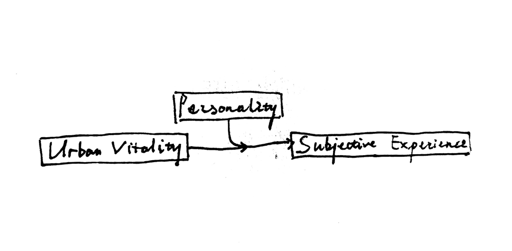

## Exploratory data analysis (EDA)

In this part, exploratory analysis will be performed.

> Descriptive Stat

Firstly, we represent descriptive statistical results. The most important of them are mean and standard deviation. Here, the function **psych::describe()** and **describeBy()** are used to report characteristics of data from both questionnaire and tobii eye-tracker.

```r
# descriptive stat results of personality data.
describe(personality %>% select(Neuroticism:`Interpersonal Trust`))
```

|  | vars | n | mean | sd | median | trimmed | mad | min | max | range | skew | kurtosis | se |
| --- | --- | --- | --- | --- | --- | --- | --- | --- | --- | --- | --- | --- | --- |
| Neuroticism | 1 | 72 | 3.550347 | 0.8595619 | 3.500 | 3.540948 | 0.7413000 | 1.625 | 5.625 | 4.000 | 0.13760328 | -0.12082410 | 0.10130034 |
| Conscientiousness | 2 | 72 | 4.368056 | 0.7132699 | 4.500 | 4.409483 | 0.5559750 | 2.375 | 5.875 | 3.500 | -0.62140902 | 0.25705031 | 0.08405966 |
| Agreeableness | 3 | 72 | 4.470486 | 0.5819668 | 4.500 | 4.493534 | 0.5559750 | 2.875 | 5.375 | 2.500 | -0.37158367 | -0.44163741 | 0.06858544 |
| Openness | 4 | 72 | 4.197917 | 0.7543156 | 4.125 | 4.209052 | 0.6486375 | 1.750 | 5.875 | 4.125 | -0.26639570 | 0.72417158 | 0.08889695 |
| Extraversion | 5 | 72 | 3.560764 | 0.8368160 | 3.500 | 3.558190 | 0.9266250 | 1.250 | 5.250 | 4.000 | -0.07581117 | -0.14139770 | 0.09861971 |
| Interpersonal Trust | 6 | 72 | 2.465278 | 0.4108253 | 2.400 | 2.448276 | 0.4447800 | 1.700 | 3.600 | 1.900 | 0.43912572 | 0.03250072 | 0.04841622 |

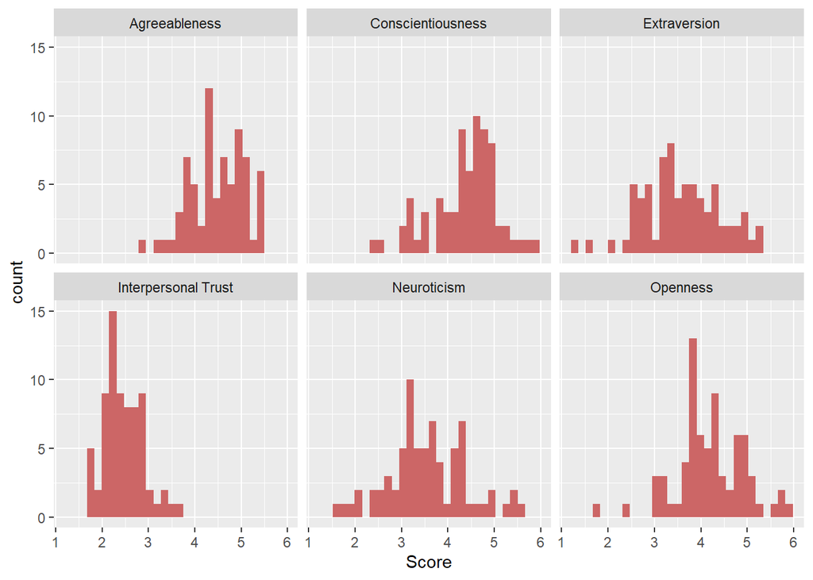

```r
# visualization: data distribution.
ggplot(personality %>% select(Neuroticism:`Interpersonal Trust`) %>% gather(everything(), key = 'Variable', value = 'Score')) +
  geom_histogram(aes(x = Score), fill = "#CC6666") +
  facet_wrap(~ Variable, nrow = 2)
```

```r
# descriptive stat results of visiting experience: note, there's 2 ways to code, in which multiple columns can be analyzed at the same time.
#   method 1: old coding style, yield an intermediate variable "for_descriptive_stat"
for_descriptive_stat <- left_join(visit_scale_score, personality[c("Key", "Level of Vitality")], by = "Key")
describeBy(x = select(for_descriptive_stat, Satisfaction:Compatibility),
  group = list(for_descriptive_stat$Scenario, for_descriptive_stat$`Level of Vitality`))
```

```
##
##  Descriptive statistics by group
## : Business District
## : High
##               vars  n mean   sd median trimmed  mad min max range  skew
## Satisfaction     1 36 4.03 1.13   4.00    4.03 0.74 2.0 6.0   4.0  0.06
## Escape           2 36 3.41 1.21   3.10    3.35 1.04 1.4 6.0   4.6  0.58
## Fascination      3 36 3.77 1.19   3.80    3.79 0.89 1.4 6.4   5.0 -0.09
## Coherence        4 36 3.67 0.87   3.75    3.62 0.74 1.5 6.0   4.5  0.41
## Compatibility    5 36 3.11 0.98   3.00    3.07 0.89 1.2 5.4   4.2  0.50
##               kurtosis   se
## Satisfaction     -0.44 0.19
## Escape           -0.54 0.20
## Fascination      -0.52 0.20
## Coherence         0.87 0.15
## Compatibility    -0.03 0.16
## ------------------------------------------------------------
## : Metro Station
## : High
##               vars  n mean   sd median trimmed  mad min  max range  skew
## Satisfaction     1 35 2.69 1.21   2.00    2.62 1.48   1 6.00  5.00  0.60
## Escape           2 35 2.29 1.11   2.00    2.17 1.19   1 5.80  4.80  1.11
## Fascination      3 35 2.62 1.09   2.60    2.54 0.89   1 5.20  4.20  0.46
## Coherence        4 35 5.06 1.03   5.25    5.07 1.48   3 6.75  3.75 -0.05
## Compatibility    5 35 2.39 0.93   2.40    2.34 0.89   1 4.60  3.60  0.39
##               kurtosis   se
## Satisfaction     -0.13 0.20
## Escape            1.17 0.19
## Fascination      -0.10 0.18
## Coherence        -1.30 0.17
## Compatibility    -0.51 0.16
## ------------------------------------------------------------
## : Night Traffic
## : High
##               vars  n mean   sd median trimmed  mad  min  max range  skew
## Satisfaction     1 36 4.06 1.22   4.00    4.03 1.48 2.00 7.00   5.0  0.27
## Escape           2 36 3.91 1.35   4.00    3.92 1.78 1.20 6.20   5.0 -0.04
## Fascination      3 36 3.60 1.07   3.50    3.58 0.74 1.60 6.60   5.0  0.38
## Coherence        4 36 4.21 1.10   4.25    4.22 1.11 1.75 6.25   4.5 -0.16
## Compatibility    5 36 3.14 1.09   3.00    3.08 1.19 1.60 5.80   4.2  0.61
```

[output cut: 66 more lines]

```
## ------------------------------------------------------------
## : Pedestrian Zone
## : Low
##               vars  n mean   sd median trimmed  mad  min max range  skew
## Satisfaction     1 36 5.39 0.90   6.00    5.43 1.48 3.00 7.0  4.00 -0.58
## Escape           2 36 4.99 0.92   5.00    5.03 0.89 3.00 7.0  4.00 -0.29
## Fascination      3 36 5.49 0.81   5.50    5.53 0.74 3.60 6.8  3.20 -0.39
## Coherence        4 36 4.18 0.71   4.12    4.20 0.93 2.25 5.5  3.25 -0.26
## Compatibility    5 36 4.17 0.75   4.20    4.18 0.89 2.60 5.8  3.20 -0.07
##               kurtosis   se
## Satisfaction     -0.19 0.15
## Escape           -0.36 0.15
## Fascination      -0.58 0.13
## Coherence        -0.21 0.12
## Compatibility    -0.77 0.13
```

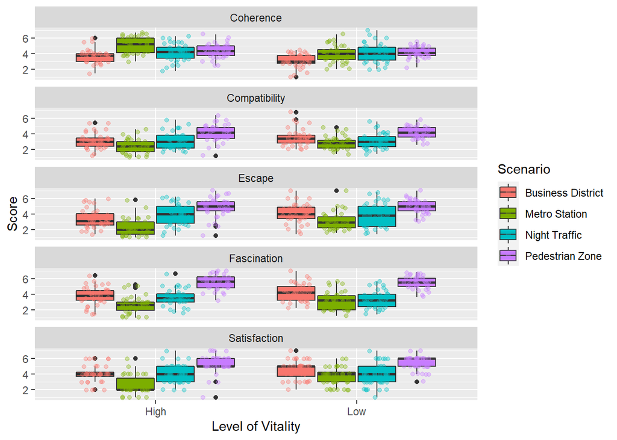

```r
#   method 2: pipe style.
# left_join(visit_scale_score, personality[c("Key", "Level of Vitality")], by = "Key") %>%
#   {describeBy(x = select(., Satisfaction:Compatibility),
#     group = list(.$Scenario, .$`Level of Vitality`))}

# data visualization:
ggplot(for_descriptive_stat %>% gather(Satisfaction:Compatibility, key = 'Variable', value = 'Score'),
       aes(x = `Level of Vitality`, y = Score)) +
  geom_boxplot(aes(fill = Scenario), position = position_dodge(0.8)) +
  geom_point(aes(color = Scenario), position = position_jitterdodge(dodge.width = 0.8, jitter.height = 0.06), alpha = 0.35) +
  facet_wrap(~ Variable, nrow = 5)
```

Please note that for “method 2” above, i.e. the latter code style, **{} is necessary**. By using it, the pipe symbol will plug the results before *only into several location* (where “.” appear), *rather than the first argument*.

Eye-tracking metrics are also analyzed, see codes below.

```r
# descriptive analysis
for_descriptive_stat <- eye_data %>% select(Key:`Level of Vitality`, Average_duration_of_whole_fixations, Average_peak_velocity_of_saccades, Average_amplitude_of_saccades, Average_pupil_size, Total_amplitude_of_saccades:Saccade_frequency, Vitality_attention, Vitality_attention_standardized)
describeBy(x = select(for_descriptive_stat, -(Key:`Level of Vitality`)),
  group = list(for_descriptive_stat$Scenario, for_descriptive_stat$`Level of Vitality`))
```

```
##
##  Descriptive statistics by group
## : Business District
## : Low
##                                     vars  n    mean     sd  median trimmed
## Average_duration_of_whole_fixations    1 36  338.47  80.25  324.00  335.80
## Average_peak_velocity_of_saccades      2 36  202.10  43.09  200.94  203.06
## Average_amplitude_of_saccades          3 36    5.76   1.25    5.78    5.79
## Average_pupil_size                     4 36    3.13   0.43    3.04    3.10
## Total_amplitude_of_saccades            5 36 1443.00 581.04 1405.49 1450.97
## Fixation_frequency                     6 36    2.04   0.51    2.06    2.05
## Duration_proportion_of_fixations       7 36    0.68   0.19    0.75    0.71
## Saccade_frequency                      8 36    1.63   0.53    1.69    1.66
## Vitality_attention                     9 36    0.08   0.04    0.07    0.08
## Vitality_attention_standardized       10 36    3.45   1.76    3.14    3.39
##                                        mad    min     max   range  skew
## Average_duration_of_whole_fixations  76.35 193.00  523.00  330.00  0.36
## Average_peak_velocity_of_saccades    42.42 101.46  277.11  175.65 -0.19
## Average_amplitude_of_saccades         1.42   2.82    8.35    5.53 -0.16
## Average_pupil_size                    0.42   2.46    4.17    1.71  0.72
## Total_amplitude_of_saccades         706.67  84.53 2497.51 2412.98 -0.08
## Fixation_frequency                    0.49   0.53    3.20    2.67 -0.37
## Duration_proportion_of_fixations      0.11   0.11    0.89    0.78 -1.33
## Saccade_frequency                     0.55   0.20    2.64    2.44 -0.47
## Vitality_attention                    0.04   0.01    0.18    0.17  0.51
## Vitality_attention_standardized       1.66   0.37    7.77    7.40  0.51
##                                     kurtosis    se
## Average_duration_of_whole_fixations    -0.61 13.38
## Average_peak_velocity_of_saccades      -0.72  7.18
## Average_amplitude_of_saccades          -0.61  0.21
## Average_pupil_size                     -0.36  0.07
## Total_amplitude_of_saccades            -0.66 96.84
## Fixation_frequency                      0.63  0.09
## Duration_proportion_of_fixations        1.12  0.03
## Saccade_frequency                       0.02  0.09
## Vitality_attention                     -0.37  0.01
## Vitality_attention_standardized        -0.37  0.29
## ------------------------------------------------------------
## : Metro Station
## : Low
```

[output cut: 234 more lines]

```
## Duration_proportion_of_fixations      0.12   0.06    0.89    0.83 -2.28
## Saccade_frequency                     0.33   0.19    2.92    2.73 -0.73
## Vitality_attention                    0.14   0.11    0.58    0.47  0.07
## Vitality_attention_standardized       1.16   0.91    4.93    4.02  0.07
##                                     kurtosis    se
## Average_duration_of_whole_fixations     1.91 12.27
## Average_peak_velocity_of_saccades      -0.71  5.48
## Average_amplitude_of_saccades           0.15  0.18
## Average_pupil_size                      0.74  0.08
## Total_amplitude_of_saccades             1.76 96.26
## Fixation_frequency                      2.56  0.10
## Duration_proportion_of_fixations        5.63  0.03
## Saccade_frequency                       1.54  0.09
## Vitality_attention                     -0.79  0.02
## Vitality_attention_standardized        -0.79  0.17
```

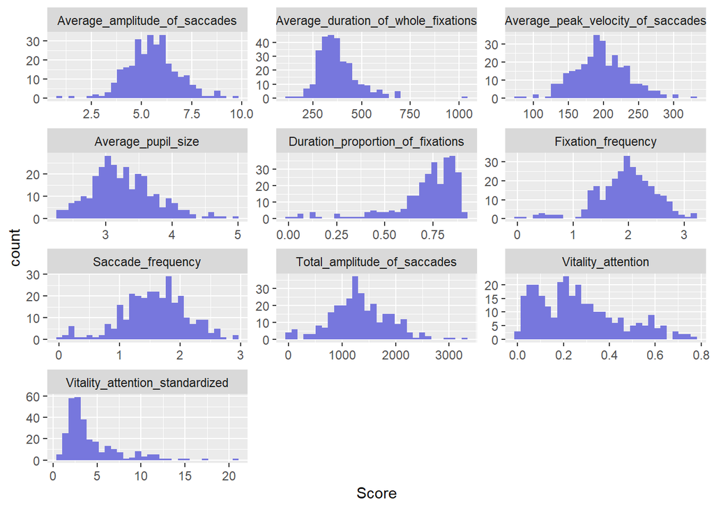

```r
# visualization: distribution
ggplot(for_descriptive_stat %>% gather(-(Key:`Level of Vitality`), key = 'Variable', value = 'Score')) +
  geom_histogram(aes(x = Score), fill = "#7777DD") +
  facet_wrap(~ Variable, ncol = 3, scales = "free")
```

> Reliability

Next, the reliability of the measurement tool should be validated. In the code below, Cronbach’s $\alpha$ coefficient of ITS and four subscale of PRS is computed.

```r
trait_trust %>% select(-Key) %>% psych::alpha()
```

```
##
## Reliability analysis
## Call: psych::alpha(x = .)
##
##   raw_alpha std.alpha G6(smc) average_r S/N   ase mean   sd median_r
##       0.65      0.67    0.71      0.17   2 0.061  2.5 0.41     0.16
##
##  lower alpha upper     95% confidence boundaries
## 0.53 0.65 0.77
##
##  Reliability if an item is dropped:
##          raw_alpha std.alpha G6(smc) average_r S/N alpha se var.r med.r
## trust_1       0.57      0.59    0.62      0.14 1.4    0.076 0.015  0.12
## trust_2       0.62      0.64    0.67      0.16 1.8    0.066 0.018  0.15
## trust_3       0.62      0.64    0.68      0.17 1.8    0.068 0.020  0.15
## trust_4       0.65      0.67    0.70      0.18 2.0    0.062 0.020  0.18
## trust_5       0.62      0.62    0.66      0.15 1.6    0.068 0.018  0.15
## trust_6       0.65      0.67    0.71      0.18 2.0    0.062 0.021  0.16
## trust_7       0.63      0.66    0.69      0.18 1.9    0.066 0.020  0.17
## trust_8       0.65      0.67    0.70      0.18 2.0    0.061 0.019  0.17
## trust_9       0.62      0.64    0.67      0.17 1.8    0.066 0.019  0.15
## trust_10      0.64      0.66    0.70      0.18 2.0    0.063 0.021  0.18
##
##  Item statistics
##           n raw.r std.r r.cor r.drop mean   sd
## trust_1  72  0.72  0.74  0.76   0.60  2.4 0.79
## trust_2  72  0.50  0.54  0.49   0.35  2.1 0.72
## trust_3  72  0.58  0.52  0.44   0.37  2.7 1.06
## trust_4  72  0.46  0.40  0.28   0.24  2.2 1.00
## trust_5  72  0.54  0.61  0.56   0.43  1.8 0.53
## trust_6  72  0.39  0.40  0.27   0.20  2.1 0.80
## trust_7  72  0.49  0.45  0.37   0.30  3.4 0.85
## trust_8  72  0.39  0.40  0.29   0.20  2.7 0.84
## trust_9  72  0.49  0.53  0.46   0.33  2.3 0.77
## trust_10 72  0.44  0.43  0.31   0.25  3.1 0.88
##
## Non missing response frequency for each item
##             1    2    3    4    5 miss
## trust_1  0.08 0.58 0.22 0.11 0.00    0
## trust_2  0.15 0.65 0.14 0.06 0.00    0
## trust_3  0.10 0.44 0.19 0.22 0.04    0
## trust_4  0.28 0.40 0.18 0.14 0.00    0
## trust_5  0.26 0.68 0.06 0.00 0.00    0
## trust_6  0.19 0.60 0.15 0.04 0.01    0
## trust_7  0.00 0.17 0.31 0.46 0.07    0
## trust_8  0.03 0.49 0.31 0.17 0.01    0
## trust_9  0.12 0.54 0.26 0.07 0.00    0
## trust_10 0.03 0.22 0.39 0.33 0.03    0
```

```r
visit_scale %>% select(Escape1:Escape5) %>% psych::alpha()
```

```
##
## Reliability analysis
## Call: psych::alpha(x = .)
##
##   raw_alpha std.alpha G6(smc) average_r S/N    ase mean  sd median_r
##       0.95      0.95    0.94       0.8  21 0.0043  3.8 1.5      0.8
##
##  lower alpha upper     95% confidence boundaries
## 0.94 0.95 0.96
##
##  Reliability if an item is dropped:
##         raw_alpha std.alpha G6(smc) average_r S/N alpha se   var.r med.r
## Escape1      0.95      0.95    0.93      0.81  17   0.0052 0.00063  0.82
## Escape2      0.94      0.94    0.93      0.80  16   0.0055 0.00032  0.80
## Escape3      0.95      0.95    0.93      0.81  17   0.0052 0.00055  0.81
## Escape4      0.94      0.94    0.92      0.80  16   0.0058 0.00035  0.79
## Escape5      0.94      0.94    0.92      0.80  16   0.0058 0.00043  0.79
##
##  Item statistics
##           n raw.r std.r r.cor r.drop mean  sd
## Escape1 287  0.90  0.91  0.87   0.85  3.6 1.5
## Escape2 287  0.92  0.92  0.89   0.87  3.7 1.7
## Escape3 287  0.90  0.91  0.87   0.85  3.8 1.6
## Escape4 287  0.93  0.93  0.91   0.89  3.9 1.6
## Escape5 287  0.93  0.93  0.91   0.89  4.1 1.7
##
## Non missing response frequency for each item
##            1    2    3    4    5    6    7 miss
## Escape1 0.08 0.20 0.22 0.21 0.18 0.08 0.02    0
## Escape2 0.09 0.21 0.20 0.14 0.18 0.15 0.04    0
## Escape3 0.06 0.17 0.23 0.19 0.20 0.13 0.03    0
## Escape4 0.06 0.19 0.18 0.18 0.22 0.14 0.04    0
## Escape5 0.07 0.14 0.19 0.11 0.26 0.17 0.06    0
```

```r
visit_scale %>% select(Fascination1:Fascination5) %>% psych::alpha()
```

```
##
## Reliability analysis
## Call: psych::alpha(x = .)
##
##   raw_alpha std.alpha G6(smc) average_r S/N    ase mean  sd median_r
##       0.93      0.93    0.92      0.73  14 0.0064    4 1.4     0.73
##
##  lower alpha upper     95% confidence boundaries
## 0.92 0.93 0.94
##
##  Reliability if an item is dropped:
##              raw_alpha std.alpha G6(smc) average_r S/N alpha se   var.r med.r
## Fascination1      0.92      0.92    0.90      0.74  11   0.0079 0.00188  0.73
## Fascination2      0.92      0.92    0.90      0.75  12   0.0076 0.00171  0.73
## Fascination3      0.91      0.91    0.89      0.72  10   0.0085 0.00041  0.72
## Fascination4      0.92      0.92    0.90      0.74  12   0.0077 0.00186  0.73
## Fascination5      0.91      0.91    0.88      0.71  10   0.0088 0.00017  0.71
##
##  Item statistics
##                n raw.r std.r r.cor r.drop mean  sd
## Fascination1 287  0.88  0.88  0.84   0.81  4.0 1.6
## Fascination2 287  0.87  0.87  0.82   0.79  3.9 1.6
## Fascination3 287  0.90  0.90  0.88   0.84  3.7 1.6
## Fascination4 287  0.87  0.87  0.82   0.80  4.2 1.6
## Fascination5 287  0.91  0.91  0.89   0.85  3.9 1.7
##
## Non missing response frequency for each item
##                 1    2    3    4    5    6    7 miss
## Fascination1 0.05 0.16 0.19 0.17 0.24 0.16 0.04    0
## Fascination2 0.05 0.19 0.23 0.16 0.17 0.15 0.05    0
## Fascination3 0.08 0.17 0.22 0.17 0.21 0.10 0.04    0
## Fascination4 0.04 0.12 0.20 0.17 0.24 0.17 0.06    0
## Fascination5 0.07 0.17 0.22 0.15 0.17 0.14 0.07    0
```

```r
visit_scale %>% select(Coherence1:Coherence4) %>% psych::alpha()
```

```
##
## Reliability analysis
## Call: psych::alpha(x = .)
##
##   raw_alpha std.alpha G6(smc) average_r S/N   ase mean  sd median_r
##       0.71      0.71    0.69      0.38 2.5 0.028  4.1 1.1     0.43
##
##  lower alpha upper     95% confidence boundaries
## 0.66 0.71 0.77
##
##  Reliability if an item is dropped:
##            raw_alpha std.alpha G6(smc) average_r S/N alpha se var.r med.r
## Coherence1      0.54      0.54    0.47      0.28 1.2    0.046 0.030  0.29
## Coherence2      0.70      0.70    0.64      0.44 2.4    0.031 0.023  0.46
## Coherence3      0.73      0.73    0.66      0.48 2.8    0.027 0.009  0.45
## Coherence4      0.59      0.59    0.54      0.32 1.4    0.043 0.037  0.40
##
##  Item statistics
##              n raw.r std.r r.cor r.drop mean  sd
## Coherence1 287  0.83  0.84  0.79   0.67  4.0 1.5
## Coherence2 287  0.67  0.67  0.49   0.41  4.0 1.5
## Coherence3 287  0.62  0.63  0.44   0.35  4.4 1.5
## Coherence4 287  0.80  0.79  0.71   0.60  4.0 1.6
##
## Non missing response frequency for each item
##               1    2    3    4    5    6    7 miss
## Coherence1 0.02 0.14 0.26 0.22 0.20 0.11 0.06    0
## Coherence2 0.03 0.16 0.22 0.20 0.19 0.17 0.02    0
## Coherence3 0.02 0.10 0.16 0.20 0.26 0.21 0.05    0
## Coherence4 0.05 0.15 0.21 0.21 0.17 0.14 0.06    0
```

```r
visit_scale %>% select(Compatibility1:Compatibility5) %>% psych::alpha()
```

```
##
## Reliability analysis
## Call: psych::alpha(x = .)
##
##   raw_alpha std.alpha G6(smc) average_r S/N   ase mean  sd median_r
##       0.85      0.85    0.83      0.53 5.7 0.014  3.3 1.1     0.53
##
##  lower alpha upper     95% confidence boundaries
## 0.82 0.85 0.88
##
##  Reliability if an item is dropped:
##                raw_alpha std.alpha G6(smc) average_r S/N alpha se  var.r med.r
## Compatibility1      0.83      0.83    0.80      0.55 4.8    0.017 0.0040  0.53
## Compatibility2      0.82      0.82    0.78      0.54 4.6    0.017 0.0027  0.54
## Compatibility3      0.82      0.82    0.78      0.53 4.5    0.017 0.0024  0.52
## Compatibility4      0.82      0.82    0.78      0.53 4.5    0.018 0.0043  0.52
## Compatibility5      0.81      0.82    0.78      0.53 4.4    0.018 0.0037  0.52
##
##  Item statistics
##                  n raw.r std.r r.cor r.drop mean  sd
## Compatibility1 287  0.78  0.77  0.68   0.63  3.4 1.5
## Compatibility2 287  0.78  0.79  0.72   0.65  2.9 1.3
## Compatibility3 287  0.79  0.80  0.73   0.67  3.2 1.4
## Compatibility4 287  0.80  0.80  0.73   0.68  3.4 1.4
## Compatibility5 287  0.81  0.80  0.74   0.68  3.6 1.5
##
## Non missing response frequency for each item
##                   1    2    3    4    5    6    7 miss
## Compatibility1 0.07 0.22 0.29 0.16 0.15 0.10 0.01    0
## Compatibility2 0.13 0.30 0.30 0.15 0.09 0.03 0.01    0
## Compatibility3 0.10 0.25 0.30 0.16 0.14 0.05 0.01    0
## Compatibility4 0.08 0.21 0.31 0.19 0.13 0.08 0.01    0
## Compatibility5 0.06 0.22 0.22 0.20 0.19 0.10 0.02    0
```

```r
vital_subjective %>% psych::alpha()
```

```
##
## Reliability analysis
## Call: psych::alpha(x = .)
##
##   raw_alpha std.alpha G6(smc) average_r S/N   ase mean   sd median_r
##       0.92      0.92    0.92      0.62  11 0.011  5.1 0.94     0.61
##
##  lower alpha upper     95% confidence boundaries
## 0.9 0.92 0.94
##
##  Reliability if an item is dropped:
##         raw_alpha std.alpha G6(smc) average_r  S/N alpha se  var.r med.r
## vital_1      0.90      0.90    0.90      0.61  9.3    0.013 0.0095  0.59
## vital_2      0.90      0.90    0.89      0.59  8.8    0.013 0.0071  0.59
## vital_3      0.91      0.91    0.91      0.62  9.9    0.012 0.0113  0.59
## vital_4      0.91      0.91    0.90      0.62  9.8    0.012 0.0110  0.59
## vital_5      0.92      0.92    0.92      0.66 11.7    0.011 0.0066  0.65
## vital_6      0.89      0.90    0.89      0.59  8.6    0.014 0.0091  0.58
## vital_7      0.91      0.91    0.91      0.64 10.4    0.011 0.0111  0.64
##
##  Item statistics
##           n raw.r std.r r.cor r.drop mean  sd
## vital_1 144  0.84  0.85  0.83   0.78  5.3 1.1
## vital_2 144  0.88  0.88  0.88   0.83  5.4 1.0
## vital_3 144  0.81  0.81  0.77   0.74  5.3 1.1
## vital_4 144  0.83  0.81  0.77   0.74  5.1 1.3
## vital_5 144  0.70  0.71  0.63   0.61  5.8 1.1
## vital_6 144  0.90  0.90  0.89   0.86  5.2 1.2
## vital_7 144  0.78  0.78  0.72   0.69  3.6 1.2
##
## Non missing response frequency for each item
##            1    2    3    4    5    6    7 miss
## vital_1 0.00 0.02 0.04 0.10 0.35 0.40 0.10    0
## vital_2 0.00 0.01 0.05 0.09 0.32 0.43 0.10    0
## vital_3 0.00 0.01 0.06 0.14 0.27 0.43 0.09    0
## vital_4 0.00 0.04 0.14 0.10 0.24 0.39 0.10    0
## vital_5 0.00 0.01 0.03 0.08 0.19 0.40 0.29    0
## vital_6 0.00 0.03 0.05 0.19 0.31 0.33 0.10    0
## vital_7 0.03 0.14 0.28 0.35 0.13 0.05 0.02    0
```

> Validity